# Guided Project: Statistical Transformations and Coordinate Systems

CIS-3901 · Module 12

Author

Dominic Rueck

Published

November 10, 2026

## My data

```r
put_in_place("fairness.csv", "data/tidy")
put_in_place("sports.csv", "data/sports")

fairness <- read_csv("data/tidy/fairness.csv", show_col_types = FALSE)
sports <- read_csv("data/sports/sports.csv", show_col_types = FALSE)

if (looks_damaged(fairness) || looks_damaged(sports)) {
  stop("One of your data files looks damaged (each row in one column): it ",
       "may have been re-saved by a spreadsheet app. Ask your instructor ",
       "for a fresh copy.", call. = FALSE)
}

# Your columns
glimpse(fairness)
```

```
Rows: 5,000
Columns: 22
$ encounter_id        <dbl> 1, 2, 3, 4, 5, 6, 7, 8, 9, 10, 11, 12, 13, 14, 15,…
$ race                <chr> "AfricanAmerican", "Caucasian", "AfricanAmerican",…
$ gender              <chr> "Male", "Male", "Male", "Male", "Female", "Female"…
$ age                 <chr> "Over 60 years", "30-60 years", "Over 60 years", "…
$ time_in_hospital    <dbl> 5, 3, 3, 3, 4, 5, 4, 7, 3, 6, 4, 5, 6, 2, 4, 11, 4…
$ num_lab_procedures  <dbl> 56, 70, 81, 12, 2, 64, 9, 55, 43, 31, 80, 71, 61, …
$ num_procedures      <dbl> 0, 6, 2, 1, 2, 1, 0, 0, 0, 2, 0, 0, 0, 2, 1, 3, 0,…
$ num_medications     <dbl> 15, 24, 17, 19, 13, 9, 8, 7, 13, 11, 14, 19, 8, 22…
$ number_diagnoses    <dbl> 5, 9, 9, 7, 6, 6, 6, 7, 7, 7, 9, 9, 5, 3, 9, 9, 9,…
$ primary_diagnosis   <chr> "Other", "Other", "Other", "Other", "Other", "Othe…
$ max_glu_serum       <chr> "None", "None", "None", "Norm", "None", "None", ">…
$ A1Cresult           <chr> "None", "None", ">7", "None", "None", "None", "Non…
$ insulin             <chr> "Steady", "No", "Up", "No", "No", "No", "No", "No"…
$ change              <chr> "Ch", "No", "Ch", "No", "No", "No", "Ch", "No", "C…
$ diabetesMed         <chr> "Yes", "Yes", "Yes", "Yes", "Yes", "No", "Yes", "N…
$ medicare            <lgl> FALSE, TRUE, FALSE, FALSE, FALSE, TRUE, FALSE, FAL…
$ medicaid            <lgl> FALSE, FALSE, FALSE, FALSE, FALSE, FALSE, FALSE, F…
$ had_emergency       <lgl> FALSE, FALSE, FALSE, FALSE, FALSE, FALSE, TRUE, FA…
$ had_inpatient_days  <lgl> TRUE, FALSE, TRUE, FALSE, FALSE, TRUE, FALSE, TRUE…
$ had_outpatient_days <lgl> FALSE, FALSE, FALSE, TRUE, TRUE, FALSE, FALSE, FAL…
$ readmitted          <chr> "NO", ">30", ">30", "NO", ">30", ">30", "NO", "NO"…
$ readmit_30_days     <dbl> 0, 0, 0, 0, 0, 0, 0, 0, 0, 0, 0, 0, 0, 0, 0, 1, 0,…
```

```r
glimpse(sports)
```

```
Rows: 7,851
Columns: 18
$ X          <dbl> 1, 2, 3, 4, 5, 6, 7, 8, 9, 10, 11, 12, 13, 14, 15, 16, 17, …
$ Date       <chr> "6/10/2022", "6/10/2022", "6/10/2022", "6/10/2022", "6/10/2…
$ Time       <time> 01:05:00, 01:25:00, 01:35:00, 01:55:00, 02:05:00, 02:30:00…
$ Player1    <chr> "Marchuk M.", "Sokolov S.", "Samofal Y.", "Kyilo V.", "Poly…
$ Player2    <chr> "Polysynskyi M.", "Sachuk S.", "Bambutsa R.", "Chernyshov D…
$ Sets_P1    <dbl> 3, 0, 3, 3, 3, 2, 3, 3, 0, 2, 3, 3, 3, 3, 0, 2, 3, 3, 3, 1,…
$ Sets_P2    <dbl> 1, 3, 1, 1, 0, 3, 1, 2, 3, 3, 0, 2, 2, 2, 3, 3, 2, 2, 1, 3,…
$ P1_G1      <dbl> 11, 12, 4, 6, 12, 11, 11, 11, 9, 9, 11, 11, 11, 11, 3, 10, …
$ P2_G1      <dbl> 8, 14, 11, 11, 10, 9, 8, 8, 11, 11, 6, 7, 5, 7, 11, 12, 5, …
$ P1_G2      <dbl> 11, 8, 11, 11, 11, 11, 11, 7, 9, 5, 13, 12, 13, 11, 3, 8, 1…
$ P2_G2      <dbl> 6, 11, 5, 1, 9, 9, 7, 11, 11, 11, 11, 10, 11, 5, 11, 11, 8,…
$ P1_G3      <dbl> 6, 5, 11, 15, 11, 5, 3, 11, 8, 11, 11, 5, 7, 9, 9, 11, 9, 1…
$ P2_G3      <dbl> 11, 11, 6, 13, 6, 11, 11, 3, 11, 7, 3, 11, 11, 11, 11, 7, 1…
$ P1_G4      <dbl> 11, NA, 11, 11, NA, 10, 11, 9, NA, 11, NA, 6, 8, 8, NA, 11,…
$ P2_G4      <dbl> 8, NA, 9, 7, NA, 12, 9, 11, NA, 6, NA, 11, 11, 11, NA, 5, 1…
$ P1_G5      <dbl> NA, NA, NA, NA, NA, 0, NA, 11, NA, 9, NA, 11, 11, 12, NA, 8…
$ P2_G5      <dbl> NA, NA, NA, NA, NA, 11, NA, 9, NA, 11, NA, 9, 8, 10, NA, 11…
$ HomeWinner <dbl> 1, 0, 1, 1, 1, 0, 1, 1, 0, 0, 1, 1, 1, 1, 0, 0, 1, 1, 1, 0,…
```

```r
# PART A · FAIRNESS ==========================================================

# A0 · Your group and your outcome ------------------------------------------
# Session 1, slide 17: "My outcome is time_in_hospital >= 5. My group is age"
# YOUR TURN: replace "replace me" with your group column (no quotes), and
# FALSE with a TRUE/FALSE condition for your outcome. Examples (use YOUR
# columns; the Guided Project page lists them for every class dataset):
#   group = sex,           has_outcome = income == ">50K"
#   group = age,           has_outcome = readmit_30_days == 1
```

## Part A · Fairness

**My group:** Age **My outcome:** time_in_hospital >= 5.

**Question A:** “Of each age group, what share has the outcome of time_in_hospital >= 5?” **Question B:** “Of everyone with time_in_hospital >= 5, what share is each age group?”

### A0 · My group and my outcome

```r
a_data <- fairness %>%
  mutate(
    group = age,
    has_outcome = time_in_hospital >= 5
  )

a_data %>%
  count(group, has_outcome) %>%
  print(n = Inf)
```

```
# A tibble: 6 × 3
  group               has_outcome     n
  <chr>               <lgl>       <int>
1 30 years or younger FALSE         106
2 30 years or younger TRUE           35
3 30-60 years         FALSE        1012
4 30-60 years         TRUE          499
5 Over 60 years       FALSE        1962
6 Over 60 years       TRUE         1386
```

### A1 · The rate within each group (question A)

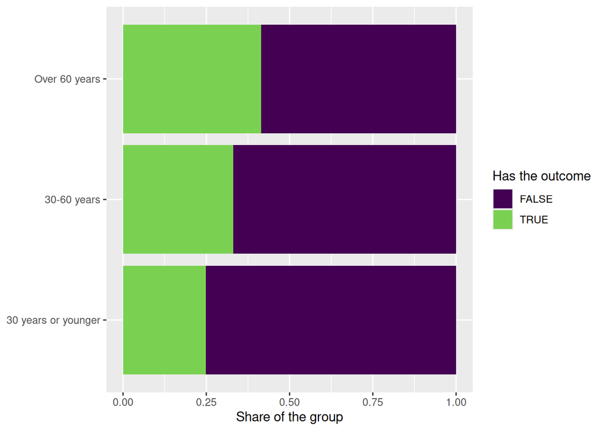

Figure 1: Share of each group with the outcome.

```r
a1 <- ggplot(a_data, aes(y = group, fill = has_outcome)) +
  geom_bar(position = "fill") +
  labs(x = "Share of the group", y = NULL, fill = "Has the outcome")

show_plot(a1)
```

I would guess that older people would have a longer time in the hospital, so I expect the highest rate to be in the older age groups. The plot shows that people over 60 have the highest share of time_in_hospital >= 5, while people under 30 have the lowest share. People between 30 and 60 years sit in between. This makes groups of different sizes comparable because it brings all groups to the same scale instead of being different just because there is more people in one group or the other.

### A2 · Rates with their standard error

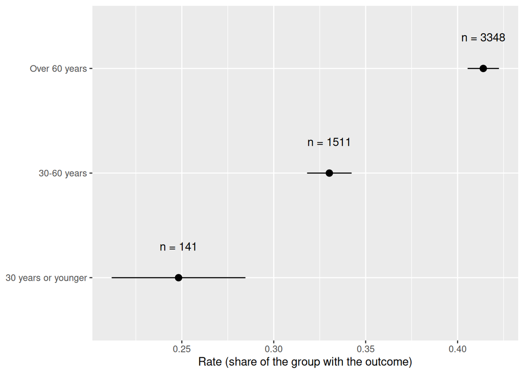

Figure 2: Rate in each group, with ± one standard error and the group size.

```r
a2_rates <- a_data %>%
  drop_na(has_outcome) %>%
  group_by(group) %>%
  summarize(
    n = n(),
    rate = mean(has_outcome),
    se = sqrt(rate * (1-rate) / n)
  )

a2 <- ggplot(a2_rates,
             aes(x = rate, y = group,
                 xmin = rate - se,
                 xmax = rate + se)) +
  geom_pointrange() +
  # Many groups, and the labels touch the points? Keep every group, and use
  # vjust = -0.8, size = 3 instead of nudge_y = 0.3.
  geom_text(aes(label = paste("n =", n)), nudge_y = 0.3) +
  labs(x = "Rate (share of the group with the outcome)", y = NULL)

show_plot(a2)
```

The youngest group has the widest range. It tells the reader that even though the group is small, it has a high variability in th e outcome. One or two outliers can already have a significant impact on the results.

### A3 · Zoom or filter?

```r
a3_table <- a_data %>%
  count(group) %>%
  arrange(desc(n))
a3_table
```

```
# A tibble: 3 × 2
  group                   n
  <chr>               <int>
1 Over 60 years        3348
2 30-60 years          1511
3 30 years or younger   141
```

```r
a3_start <- 120

a3_counts <- ggplot(a_data, aes(y = group)) +
  geom_bar() +
  labs(x = "Count", y = NULL)

a3_zoom <- a3_counts +
  coord_cartesian(xlim = c(a3_start, max(a3_table$n)), expand = FALSE)

# A warning about removed rows here is expected (Session 2, slide 5).
a3_filter <- a3_counts +
  scale_x_continuous(limits = c(a3_start, max(a3_table$n)))

# Lie Factor (Tufte, 2001, p. 57) of the zoomed plot, largest vs smallest
# group: how many times the picture exaggerates the difference.
a3_largest <- max(a3_table$n)
a3_smallest <- min(a3_table$n)
a3_lie_factor <-
  ((a3_largest - a3_start) / (a3_smallest - a3_start)) /
  (a3_largest / a3_smallest)
a3_lie_factor
```

```
[1] 6.47363
```

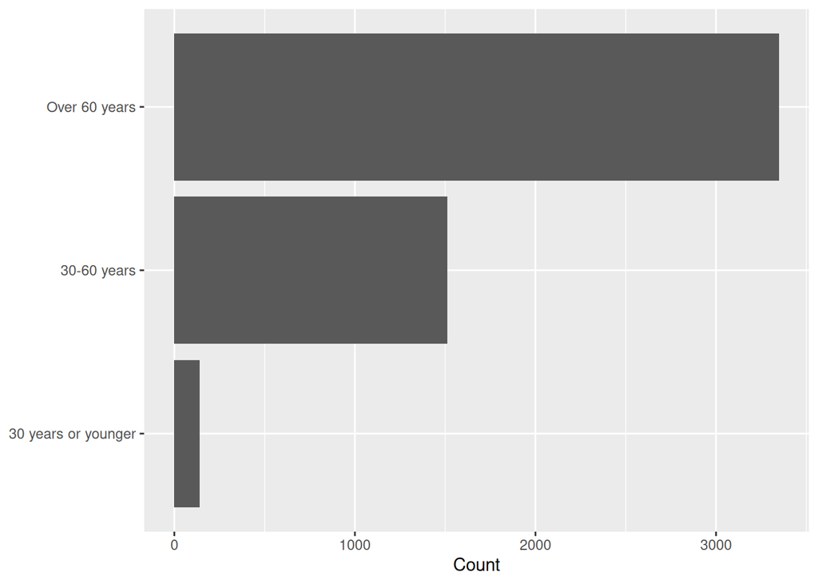

(a) From 0

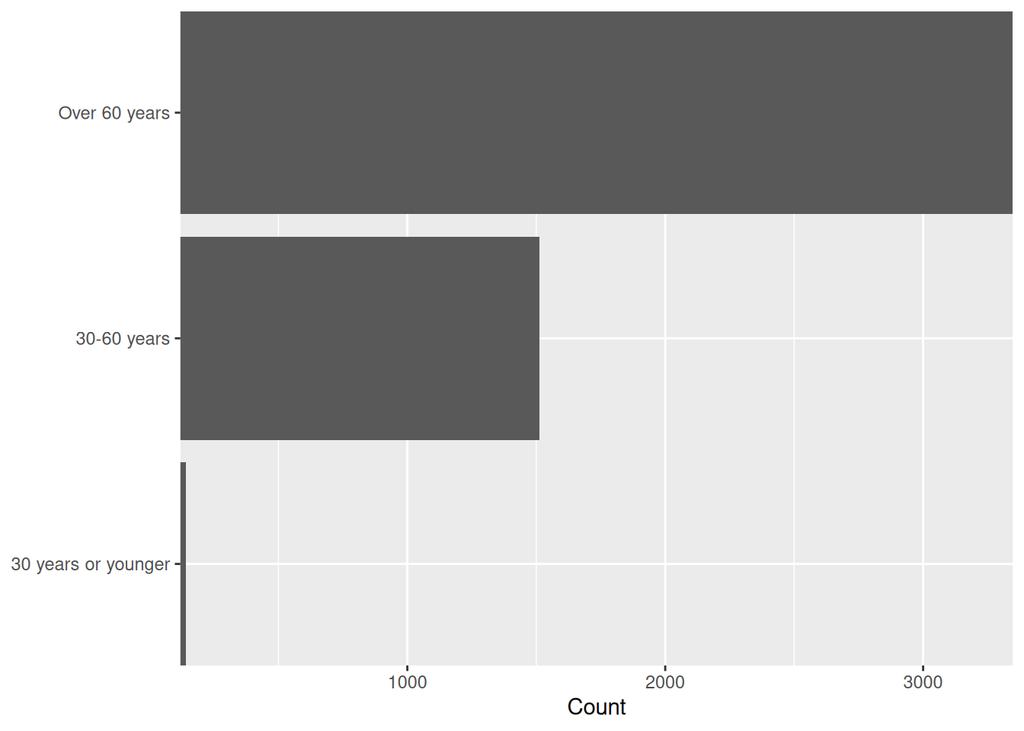

(b) Zoomed

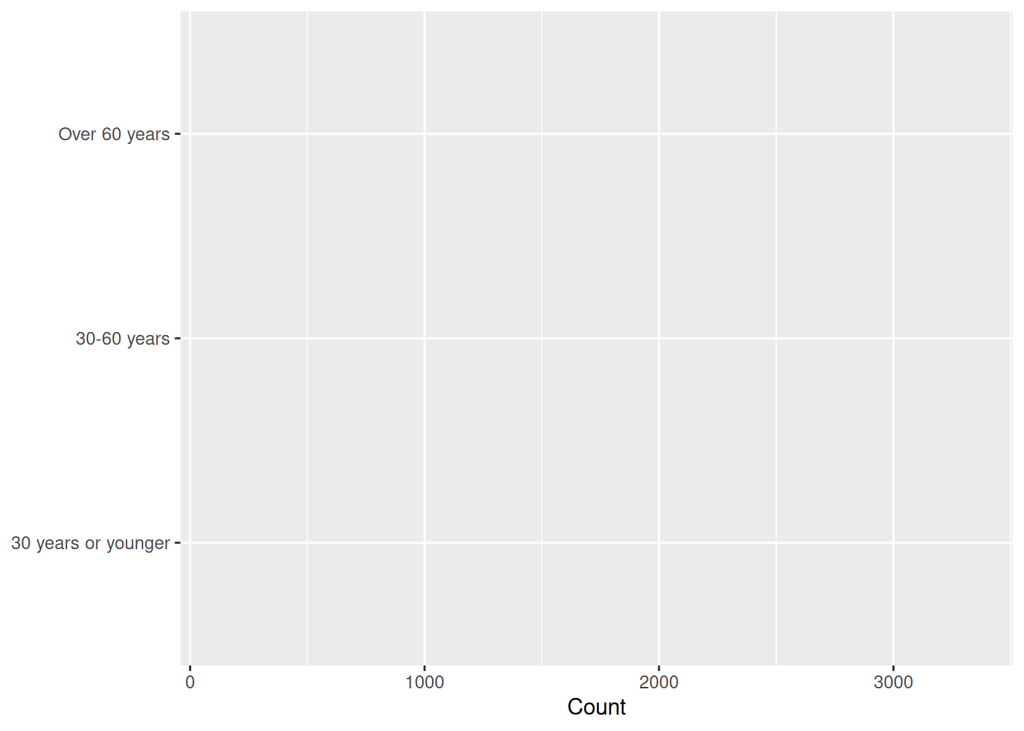

(c) Filtered

Figure 3: Counts per group: from 0, zoomed and filtered.

```r
show_plot(a3_counts)
show_plot(a3_zoom)
show_plot(a3_filter)
```

The zoomed plot’s Lie Factor (largest vs smallest group) is 6.5.

### A4 · Each group’s share of everyone with the outcome (question B)

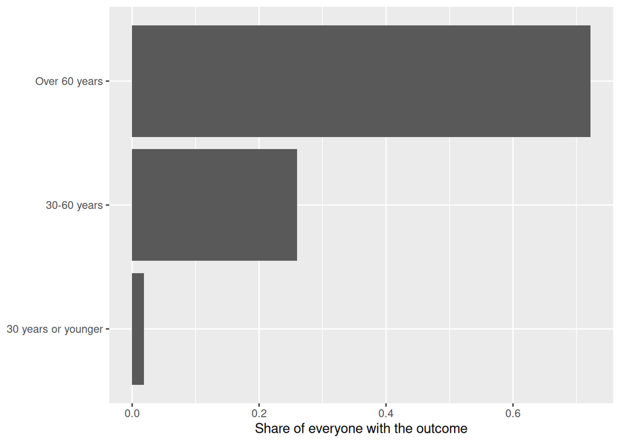

Figure 4: Each group’s share of everyone with the outcome.

```r
a4_shares <- a_data %>%
  filter(has_outcome) %>%
  count(group) %>%
  mutate(share = n / sum(n))

a4 <- ggplot(a4_shares, aes(x = share, y = group)) +
  geom_col() +
  labs(x = "Share of everyone with the outcome", y = NULL)

show_plot(a4)
```

They do point in the same direction since the plots always confirm each other. Already in the beginning, the oldest group stood out which was then confirmed throughout.

## Part B · Sports

**My group, outcome and value:** group = the number of of sets played in the match, outcome = the home player won, value = the total points sccored in game 1.

### B0 · My group, outcome and value

```r
b_data <- sports %>%
  mutate(
    group = factor(Sets_P1 + Sets_P2),
    has_outcome = HomeWinner == 1,
    value = P1_G1 + P2_G1
  )

b_data %>%
  count(group, has_outcome) %>%
  print(n = Inf)
```

```
# A tibble: 6 × 3
  group has_outcome     n
  <fct> <lgl>       <int>
1 3     FALSE        1200
2 3     TRUE         1206
3 4     FALSE        1478
4 4     TRUE         1449
5 5     FALSE        1274
6 5     TRUE         1244
```

```r
summary(b_data$value)
```

```
   Min. 1st Qu.  Median    Mean 3rd Qu.    Max.
  11.00   17.00   18.00   18.69   20.00   44.00
```

### B1 · The rate within each group

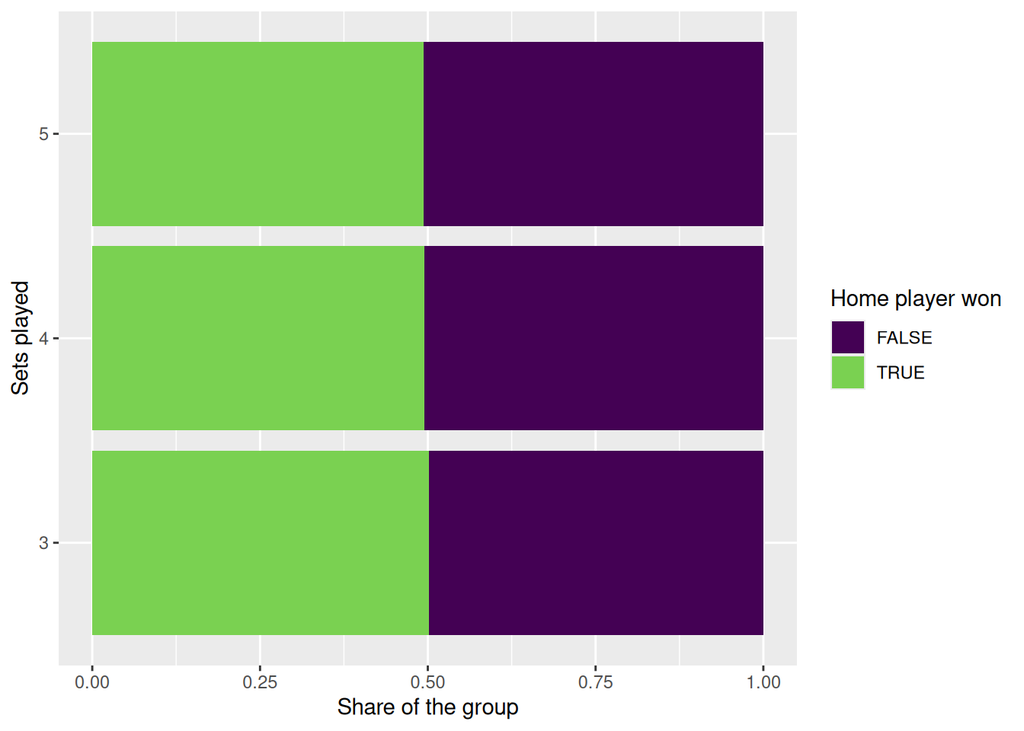

Figure 5: Share of each group with the outcome.

```r
b1 <- ggplot(b_data, aes(y = group, fill = has_outcome)) +
  geom_bar(position = "fill") +
  labs(x = "Share of the group", y = "Sets played", fill = "Home player won")

show_plot(b1)
```

The home player won about 50% of the matches (50.1%) in the 3-set matches, 49.5% in the 4-set matches, and 49.4% in the 5-set matches, so the link of the matches shows almost no connection to who wins. I use shares because the groups are of different sizes and it makes them comparable.

### B2 · A mean with its two spreads

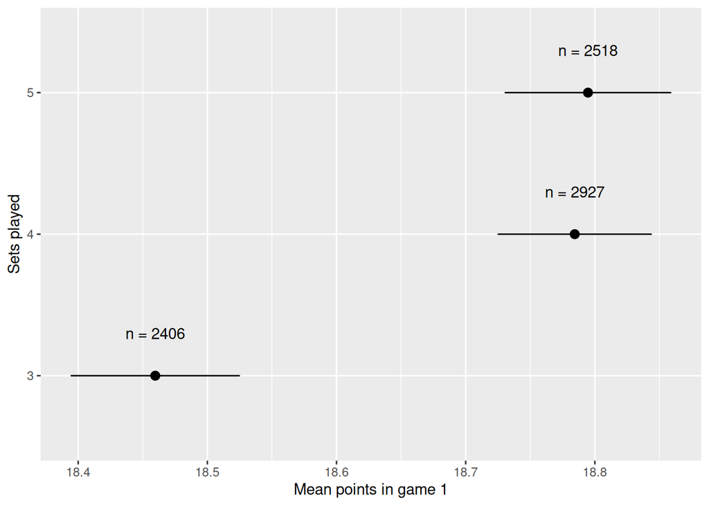

Figure 6: Mean in each group, with ± one standard error and group size.

```r
b2_summary <- b_data %>%
  drop_na(value) %>%
  group_by(group) %>%
  summarize(
    n = n(),
    mean = mean(value),
    sd = sd(value),
    se = sd / sqrt(n)
  )

b2 <- ggplot(b2_summary,
             aes(x = mean, y = group,
                 xmin = mean - se,
                 xmax = mean + se)) +
  geom_pointrange() +
  geom_text(aes(label = paste("n =", n)), nudge_y = 0.3) +
  labs(x = "Mean points in game 1", y = "Sets played")


show_plot(b2)
```

Table 1: Group size, mean, sd and se.

| group | n | mean | sd | se |
| --- | --- | --- | --- | --- |
| 3 | 2406 | 18.460 | 3.212 | 0.065 |
| 4 | 2927 | 18.784 | 3.226 | 0.060 |
| 5 | 2518 | 18.795 | 3.236 | 0.064 |

The mean of game 1 is about 18.5 points for 3-set matches and about 18.8 points for 4- and 5-set matches, a gap of about 0.3 points. This gap is large compared to the se (each bar is only about ±0.06 points wide, and the 3-set bar does not overlap the other two), so it is unlikely to be just sampling noise. We should take from this that there is a small, fairly clear difference between the averages, not a difference that would let anyone predict the length of a match from its first game.

### B3 · Zoom or filter?

```r
b3_table <- b_data %>%
  count(group) %>%
  arrange(desc(n))
b3_table
```

```
# A tibble: 3 × 2
  group     n
  <fct> <int>
1 4      2927
2 5      2518
3 3      2406
```

```r
b3_start <- floor(min(b3_table$n) / 2)

b3_counts <- ggplot(b_data, aes(y = group)) +
  geom_bar() +
  labs(x = "Count", y = "Sets played")

b3_zoom <- b3_counts +
  coord_cartesian(xlim = c(b3_start, max(b3_table$n)), expand = FALSE)

b3_filter <- b3_counts +
  scale_x_continuous(limits = c(b3_start, max(b3_table$n)))

b3_lie_factor <-
  ((max(b3_table$n) - b3_start) / (min(b3_table$n) - b3_start)) /
  (max(b3_table$n) / min(b3_table$n))
b3_lie_factor
```

```
[1] 1.177998
```

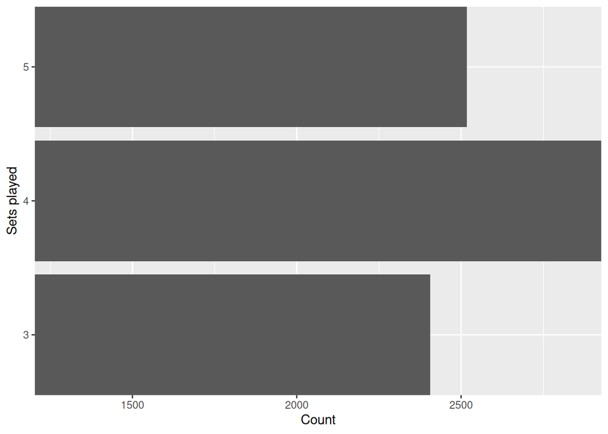

(a) Zoomed

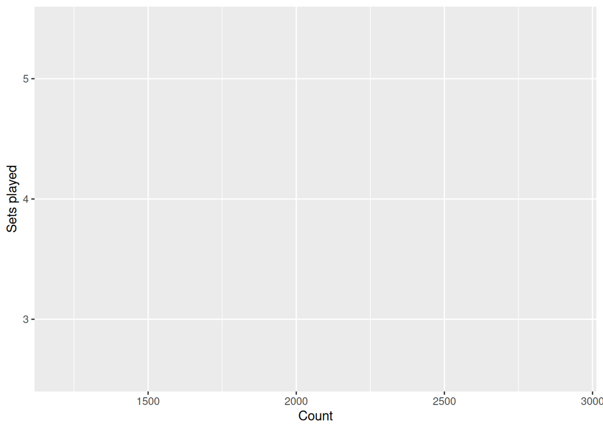

(b) Filtered

Figure 7: Counts per group: zoomed and filtered.

```r
show_plot(b3_zoom)
show_plot(b3_filter)
```

The Lie Factor of your zoomed plot is 1.18. The zoomed plot makes the 4 matches seem much more common than the other two even though they are pretty close. The filtered version removes the bars completely because they start at 0, which is outside of the limits.

### B4 · Each group’s share of everyone with the outcome

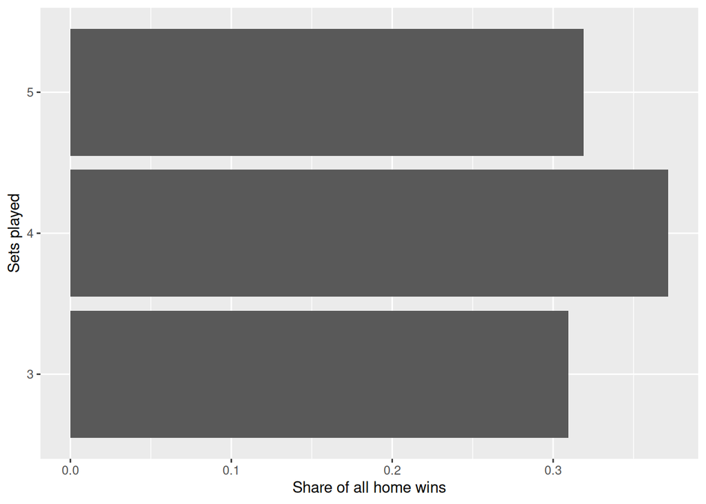

Figure 8: Each group’s share of everyone with the outcome.

```r
b4_shares <- b_data %>%
  filter(has_outcome) %>%
  count(group) %>%
  mutate(share = n / sum(n))

b4 <- ggplot(b4_shares, aes(x = share, y = group)) +
  geom_col() +
  labs(x = "Share of all home wins", y = "Sets played")

show_plot(b4)
```

B4 does not point in the same direction as B1. B1 shows almost no difference while B4 shows that 4-set matches have the largest share. This is more likely because there are more 4-set matches in total, so they make up the biggest part of the home wins just because they are the biggest group.

## Checks

Table 2: Every task’s check, at the time this page was rendered.

| task | status |
| --- | --- |
| A0 | PASS |
| A1 | PASS |
| A2 | PASS |
| A3 | PASS |
| A4 | PASS |
| B0 | PASS |
| B1 | PASS |
| B2 | PASS |
| B3 | PASS |
| B4 | PASS |

## AI use

No AI used.

## References

**Fairness:** Clore, J., Cios, K., DeShazo, J., & Strack, B. (2014). Diabetes 130-US Hospitals for Years 1999-2008 [Dataset]. UCI Machine Learning Repository. https://doi.org/10.24432/C5230J.

**Sports:** Cassidy, G. (2024, July 17). Setka table tennis dataset – SCORE sports data repository. Scorenetwork.Org. https://data.scorenetwork.org/table_tennis/table_tennis_sept2022.html